# Initial Analysis: Teacher Estimates of Workload

Zach Schroeder

2/6/2021

Weekly workload of an internationally representative sample of teachers. Each teacher was asked to report the number of hours they worked during the last week using three separate prompts:

- *Hours in Classroom:* How many 60-minute hours did you spend on teaching at this school during your most recent complete calendar week?
- *General Estimate:* During your most recent complete calendar week, approximately how many 60-minute hours did you spend in total on tasks related to your job at this school?
- *Specific Estimate:* Approximately how many 60-minute hours did you spend on the following tasks during your most recent complete calendar week, in your job at this school?
  - How many 60-minute hours did you spend on teaching at this school during your most recent complete calendar week?
  - Individual planning or preparation of lessons either at school or out of school
  - Team work and dialogue with colleagues within this school
  - Marking/correcting of student work
  - Counseling students (including student supervision, mentoring, virtual counselling, career guidance and behaviour guidance)
  - Participation in school management
  - General administrative work (including communication, paperwork and other clerical duties)
  - Professional development activities
  - Communication and co-operation with parents or guardians
  - Engaging in extracurricular activities (e.g. sports and cultural activities after school)
  - Other work tasks

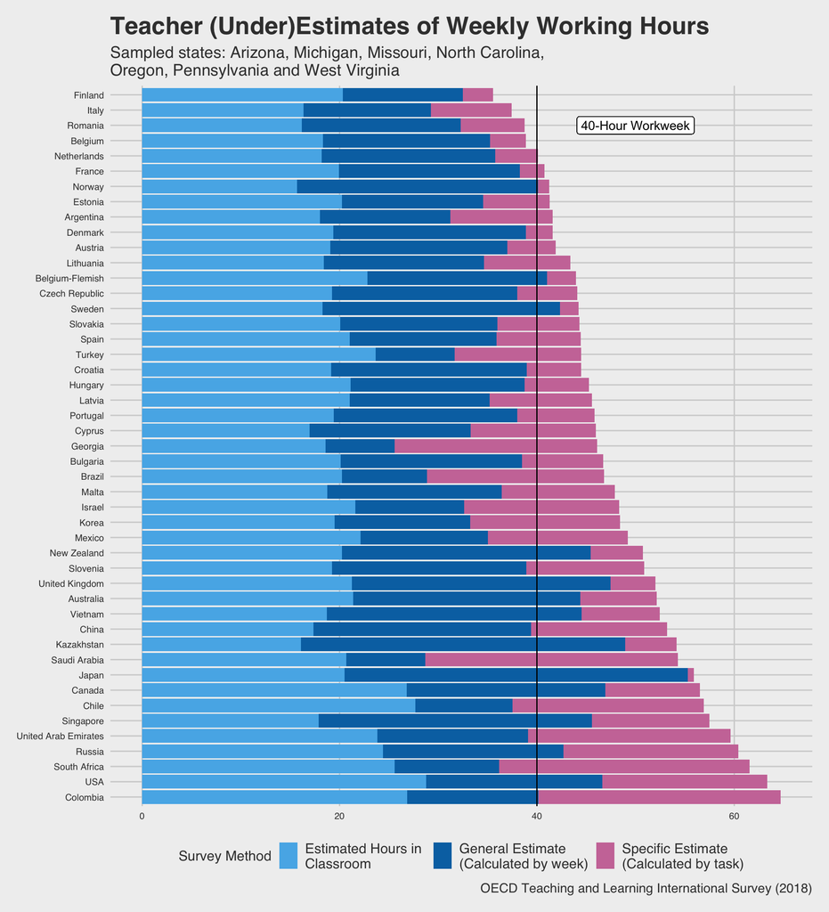

*Table 1: International Estimates of Teacher Workload*

| Country | Classroom Hours | General Estimate | Specific Estimate |
| --- | --- | --- | --- |
| Finland | 20.31 | 32.50 | 35.55 |
| Italy | 16.34 | 29.28 | 37.42 |
| Romania | 16.17 | 32.28 | 38.74 |
| Belgium | 18.32 | 35.25 | 38.90 |
| Netherlands | 18.20 | 35.77 | 40.09 |
| France | 19.93 | 38.27 | 40.78 |
| Norway | 15.68 | 40.11 | 41.22 |
| Estonia | 20.24 | 34.53 | 41.30 |
| Argentina | 17.99 | 31.22 | 41.58 |
| Denmark | 19.38 | 38.87 | 41.59 |
| Austria | 19.04 | 37.02 | 41.89 |
| Lithuania | 18.39 | 34.62 | 43.40 |
| Belgium-Flemish | 22.82 | 41.02 | 43.95 |
| Czech Republic | 19.22 | 38.00 | 44.11 |
| Sweden | 18.29 | 42.32 | 44.21 |
| Slovakia | 20.05 | 35.98 | 44.30 |
| Spain | 21.04 | 35.91 | 44.45 |
| Turkey | 23.67 | 31.68 | 44.47 |
| Croatia | 19.14 | 38.97 | 44.48 |
| Hungary | 21.12 | 38.74 | 45.29 |
| Latvia | 21.02 | 35.20 | 45.56 |
| Portugal | 19.40 | 37.99 | 45.84 |
| Cyprus | 16.94 | 33.30 | 45.98 |
| Georgia | 18.57 | 25.57 | 46.08 |
| Bulgaria | 20.10 | 38.50 | 46.73 |
| Brazil | 20.26 | 28.86 | 46.80 |
| Malta | 18.77 | 36.45 | 47.90 |
| Israel | 21.60 | 32.63 | 48.34 |
| Korea | 19.50 | 33.24 | 48.44 |
| Mexico | 22.13 | 35.02 | 49.19 |
| New Zealand | 20.26 | 45.44 | 50.74 |
| Slovenia | 19.22 | 38.94 | 50.86 |
| United Kingdom | 21.23 | 47.46 | 52.01 |
| Australia | 21.36 | 44.41 | 52.16 |
| Vietnam | 18.69 | 44.53 | 52.46 |
| China | 17.37 | 39.40 | 53.20 |
| Kazakhstan | 16.08 | 48.93 | 54.14 |
| Saudi Arabia | 20.69 | 28.68 | 54.27 |
| Japan | 20.52 | 55.29 | 55.91 |
| Canada | 26.80 | 46.94 | 56.50 |
| Chile | 27.70 | 37.53 | 56.91 |
| Singapore | 17.87 | 45.57 | 57.47 |
| United Arab Emirates | 23.84 | 39.09 | 59.65 |
| Russia | 24.39 | 42.68 | 60.41 |
| South Africa | 25.60 | 36.18 | 61.56 |
| USA | 28.76 | 46.63 | 63.32 |
| Colombia | 26.84 | 40.16 | 64.69 |